# Flt3 Nfkb1 scRNAseq + CITE-seq + Hashtag analysis

V2 Manual HTO Demux

- scrublet #done
- Mt content #done
- cell cycle regression #no
- neo/snpclust, compare to hashtag
- hashtag,
- gene/totalRNA counts
- GateID #does not apply

Mt content -> scrublet -> HTO_Demux (veryfy with neo/snpclust) -> gene/totalRNA counts -> cell cycle -> same to d5 -> aggregate?

normalize -> find variable -> scale

- Manually ID doublet, redo #done
- CellCycleScoring
- Suggest Eason to look at surface markers
- Stat5a genes

```r
Sys.setenv("DISPLAY"=":0")
library(dplyr)
```

```r
library(Seurat)
library(data.table)
```

```r
# Load the DC D3 RNA dataset
d3.data <- Read10X(data.dir = "../rna_d3/outs/filtered_feature_bc_matrix/")
# 8734 cells
# Initialize the Seurat object with the raw (non-normalized data).
d3 <- CreateSeuratObject(counts = d3.data, project = "DC", min.cells = 3, min.features = 200)
# 8696 cells
```

```r
# The [[ operator can add columns to object metadata. This is a great place to stash QC stats
d3[["percent.mt"]] <- PercentageFeatureSet(d3, pattern = "^mt-")
```

```r
# preview a few cells and genes
d3.data[c("mt-Nd1", "mt-Nd2", "mt-Co1"), 1:30]
```

```
3 x 30 sparse Matrix of class "dgCMatrix"
```

```
   [[ suppressing 30 column names ‘AAACCCAAGAAGTGTT’, ‘AAACCCAAGAATAGTC’, ‘AAACCCAAGATTAGCA’ ... ]]
```

```
mt-Nd1  2 2 154  7  21  32   8  28  9  2  81 195 102  5  7 1 26  1 20 144  16  1  57  4 24  4  6
mt-Nd2  8 2 134 10  23  60  15  34 23  4 113 169 143  9  7 3 28  . 18 154  34  6  71 11 20  8  9
mt-Co1 13 8 234 40 183 104 133 118 76 24 262 515 288 34 42 5 83 24 77 325 122 27 189 33 76 33 27

mt-Nd1 176  66  90
mt-Nd2 185  99 109
mt-Co1 351 151 338
```

```r
# Show QC metrics for the first 5 cells, mito genes, etc.
head(d3@meta.data, 5)
```

|  | orig.ident | nCount_RNA | nFeature_RNA | percent.mt |
| --- | --- | --- | --- | --- |
| AAACCCAAGAAGTGTT | DC | 1900 | 1025 | 2.315789 |
| AAACCCAAGAATAGTC | DC | 572 | 440 | 3.496503 |
| AAACCCAAGATTAGCA | DC | 36065 | 5450 | 6.674061 |
| AAACCCAAGGATTACA | DC | 6695 | 2070 | 3.345780 |
| AAACCCAAGTACCATC | DC | 11854 | 3228 | 5.593049 |

```r
tail(d3@meta.data[order(d3@meta.data$percent.mt),],10)
```

|  | orig.ident | nCount_RNA | nFeature_RNA | percent.mt |
| --- | --- | --- | --- | --- |
| TCGGGCATCGCATAGT | DC | 2135 | 307 | 80.74941 |
| AGATAGAAGCGTCGAA | DC | 2509 | 358 | 82.14428 |
| TCGTAGACATACTGAC | DC | 2425 | 340 | 82.14433 |
| AGATAGATCATGGCCG | DC | 3170 | 384 | 82.52366 |
| ACTACGATCGAACGGA | DC | 1732 | 226 | 82.79446 |
| ATTATCCCATCAGTCA | DC | 1876 | 229 | 82.88913 |
| ACGTAGTTCAGGAACG | DC | 2276 | 259 | 84.49033 |
| AATGGAATCTCTGAGA | DC | 3121 | 281 | 87.98462 |
| TACCTGCTCGAGAATA | DC | 2706 | 215 | 88.50702 |
| GTGGAGAAGCGCCTAC | DC | 2716 | 241 | 88.65979 |

```r
mtHighExample <- d3.data[,'TCGGGCATCGCATAGT']
mtHighExample[mtHighExample != 0]
```

[output not shown]

[output cut: 49 more lines]

[output not shown]

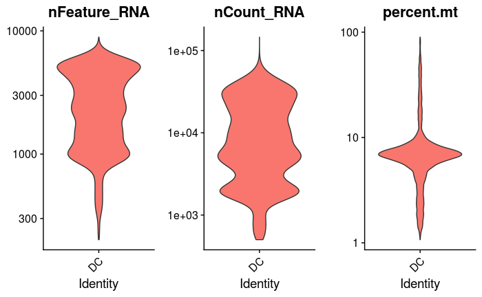

```r
# Visualize QC metrics as a violin plot
VlnPlot(d3, features = c("nFeature_RNA", "nCount_RNA", "percent.mt"), ncol = 3, pt.size = 0, log = TRUE)
```

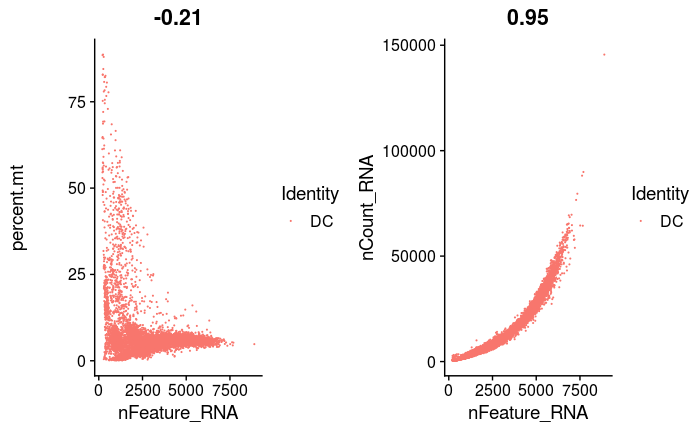

```r
# FeatureScatter is typically used to visualize feature-feature relationships, but can be used
# for anything calculated by the object, i.e. columns in object metadata, PC scores etc.
plot1 <- FeatureScatter(d3, feature1 = "nFeature_RNA", feature2 = "percent.mt", pt.size = 0.1)
plot2 <- FeatureScatter(d3, feature1 = "nFeature_RNA", feature2 = "nCount_RNA", pt.size = 0.1)
CombinePlots(plots = list(plot1, plot2))
```